# Introduction to IBMs for infectious diseases

# Objectives

The aim of this tutorial is to introduce you to individual-based modelling for infectious diseases in R. The dynamics of the stochastic model we target here cannot be captured by ordinary differential equations. In this session, you will:

1. Create an IBM population with random movement
2. Include Susceptible-Infected-Recovered disease dynamics
3. Run over multiple time steps and analyse transmission dynamics

The best thing to do is to read each section and type (or copy and paste) the R commands (in grey boxes) into your own R session to check that you understand the code. Hands-on questions are indicated in **red**

# Modelling concepts

Modelling goals:

- Learn about random numbers in R
- To create a population `data.frame` (= matrix) with one row per individual and one column per person characteristic
- Add a [random walk](https://en.wikipedia.org/wiki/Random_walk) (with borders)
- Add health states: susceptible (S), infected (I) and recovered (R)
- Add transmission and recovery dynamics
- Combine everything into a loop to process multiple time steps

# Set working directory

The first step when creating a new R file is to specify a working directory. You need to tell the R session where you want it to work. To do this you use the command to “set the working directory” or `setwd()`.

You can label this working directory as ‘home’, and have other locations stored for plotting or for getting data. This location should be an existing folder on your computer. For example

```r
home = "~/Documents/Modelling_intro/" ## on a OS X
home = "C:\\Documents\\Modelling_intro\\" ## on windows
setwd(home)
```

# Random numbers in R

In R, you can generate random numbers using for example `sample`, `runif`, `rnorm`, `rbinom`. Please have a look at:

```r
?sample
?runif
?rnorm
?rbinom
?set.seed
```

Which function is used to sample from a uniform, [normal](https://en.wikipedia.org/wiki/Normal_distribution) or [binomial](https://en.wikipedia.org/wiki/Binomial_distribution) distribution?

Random numbers in R (and other computer programs) are derived from a [random number generator](https://en.wikipedia.org/wiki/Random_number_generation), which you can initiate with `set.seed`. Seeding the random stream is very useful to obtain stochastic results that are reproducible. As such, you can check whether model output has changed (or not) if you continue programming.

For example, set the random seed to ‘2020’ and sample 3 numbers between 1 and 10, and sample 15 numbers with replacement.

```r
set.seed(2020)
sample(x = 1:10, size = 3)
sample(x = 1:10, size = 15, replace = T)
```

What happens if you do this again, with and without the `set.seed` operation? Do you get the same random numbers?

It is also possible to sample from a binomial distribution for different individuals at once.

```r
# set number of samples, a probability vector and the number of trials to execute
num_samples = 4
p_vector    = c(0, 0.5, 0.9, 1)
num_trials  = 1

# sample from the binomial distribution, for each given probability
binom_sample = rbinom(num_samples, num_trials, p_vector)

# if the sample is 1, we have a success
binom_sample
binom_sample == 1
```

# Setup the population

For this tutorial, we will use a matrix to store the population using one row per individual and one column per person characteristic. We will use a special matrix format, called `data.frame`, in which you can easily access columns using the column names. The following code illustrates the usefulness of the `data.frame` and how to access and modify elements.

```r
# inspect data.frame
?data.frame

# create a data.frame with columns 'id' and 'age'
new_data = data.frame(id  = c(1:4),      # set id's from 1 up to 4
                      age = c(5, 8, 9, 1)  # set ages
                      )

# we can access all ages using:
new_data$age

# we can access the age of the 2nd person
new_data$age[2]

# or change the age of the person with id == 3
new_data$age[new_data$id == 3] = 10

# inspect the data.frame, anything changed?
new_data
```

Now, let us create a `data.frame` for a population of 300 individuals with a health state together with a x- and y coordinate. During the set-up, we randomly locate each person in a 10x10 area.

```r
pop_size    = 300
area_size   = 10    # 10x10 square
xy_coordinates = seq(0, area_size, 0.01)  # get sequence per 0.01

# set-up population: one row per individual, one column per attribute, row index = id
pop_data     = data.frame(health  = rep('S', length = pop_size),  # all individuals start in state 'S' (= susceptible)
                          x_coord = sample(x = xy_coordinates, size = pop_size, replace = T), # sample random x coordinate
                          y_coord = sample(x = xy_coordinates, size = pop_size, replace = T), # sample random y coordinate
                          stringsAsFactors    = FALSE)         # option to treat characters as 'strings' instead of 'factors'
```

Can you check the dimensions of the pop_data matrix?

```
## [1] 300   3
```

# Random walk

We want to simulate a random walk process with a given maximum velocity. The direction and distance should be randomized. As such, we set a maximum distance and create a function to apply the random walk during one time step.

```r
# set max velocity = maximum distance per time step
max_velocity = 1   # squares per day

random_walk = function(pop_data, max_velocity){
  # step 1: move each person at random along the x and y axis
  pop_data$x_coord = pop_data$x_coord + runif(n = pop_size, min = -max_velocity, max = max_velocity)
  pop_data$y_coord = pop_data$y_coord + runif(n = pop_size, min = -max_velocity, max = max_velocity)

  # step 2: if an individual crosses a model boundary: set back at the border
  pop_data$x_coord[pop_data$x_coord > area_size] = area_size
  pop_data$y_coord[pop_data$y_coord > area_size] = area_size
  pop_data$x_coord[pop_data$x_coord < 0] = 0
  pop_data$y_coord[pop_data$y_coord < 0] = 0

  # return the adjusted population data.frame
  return(pop_data)
}
```

If you want to visualize the random walk, you can create a plot before and after applying the function. Please note that it is possible to highlight a one individual using `points`:

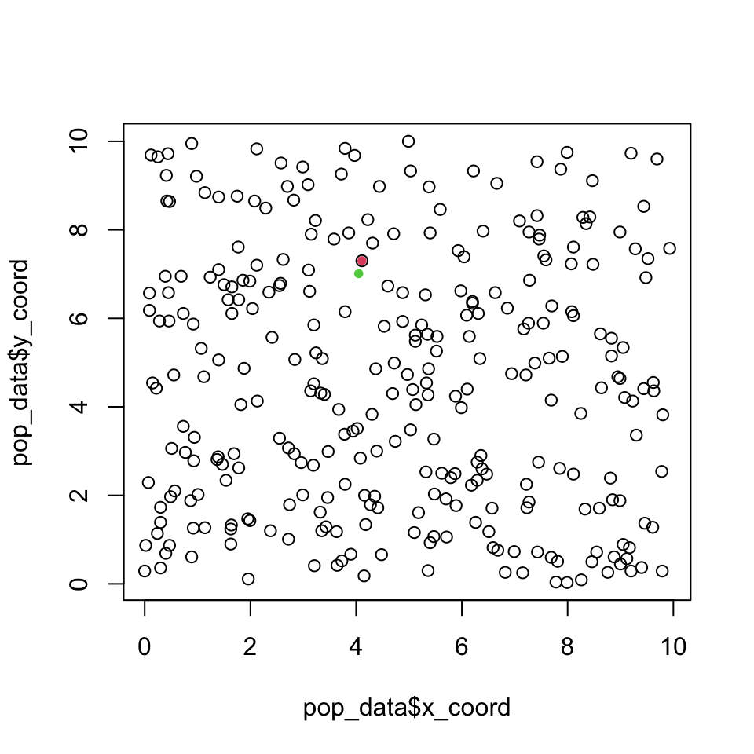

```r
# plot the area and all individuals, using color 1 (= black)
plot(x = pop_data$x_coord,
     y = pop_data$y_coord,
     col = 1)

# highlight one individual, using color 2 (= red)
points(x = pop_data$x_coord[1],
       y = pop_data$y_coord[1],
       pch = 20, # other symbol
       col = 2)

# update population
pop_data = random_walk(pop_data, max_velocity)

# highlight the selected individual again, using color 3 (= green)
points(x = pop_data$x_coord[1],
       y = pop_data$y_coord[1],
       pch = 20, # other symbol
       col = 3)
```

# Social contacts (based on proximity)

We assume that susceptible individuals can acquire an infection if they are close to an infected individual. We define proximity here with a maximum distance in terms of `max_contact_distance`. To probability for a social contact, depends on the number people that are within the specified range and the population-based average number of social contacts individuals have per time step (= per day).

```r
# set proximity parameter and the population-based average number of contacts per day
max_contact_distance = 1
target_num_contacts_day = 5

# calculate the distance matrix using the 'dist' function and store as matrix
distance_matrix = as.matrix(dist(pop_data[, c('x_coord', 'y_coord')], upper = T))

# create a matrix with Booleans whether individuals are close enough
eligible_contacts_matrix = distance_matrix <= max_contact_distance

# set the diagonal to FALSE, to prevent self-contacts
diag(eligible_contacts_matrix) = FALSE
```

Let’s visualize this:

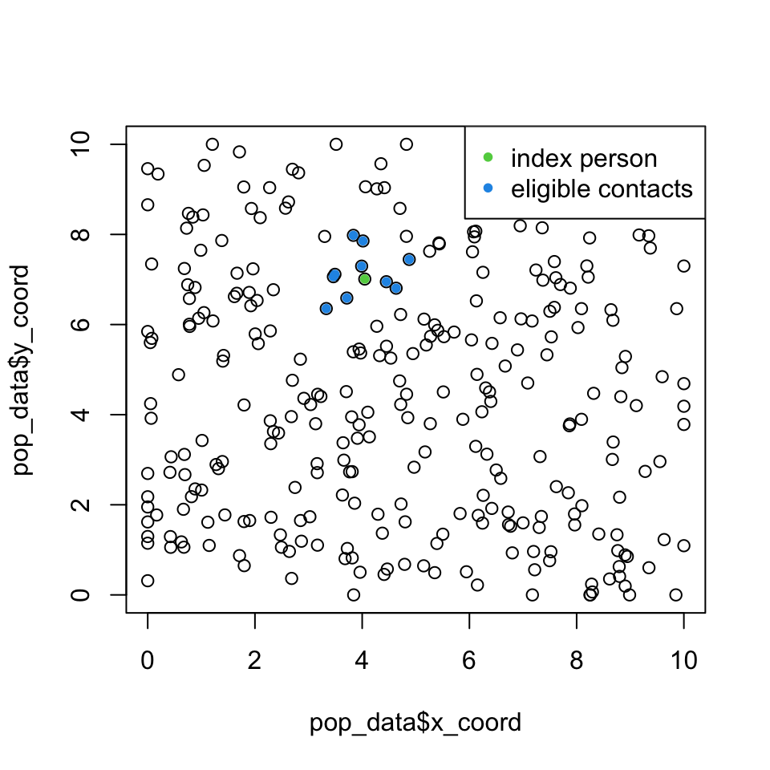

```r
# which individuals are close enough to our index person?
plot(x = pop_data$x_coord,
     y = pop_data$y_coord)
points(x = pop_data$x_coord[1],
       y = pop_data$y_coord[1],
       col = 3,
       pch = 20)
points(x = pop_data$x_coord[eligible_contacts_matrix[1, ]],
       y = pop_data$y_coord[eligible_contacts_matrix[1, ]],
       pch = 20,
       col = 4)
legend('topright',
       c('index person',
       'eligible contacts'),
       col = c(3, 4),
       pch = c(20, 20))
```

Now, we will write a function to count the number of individuals that are close enough, and calculate the probability for a social contact with each of them. Please note that Boolean’s can be summed, using TRUE as 1 and FALSE as 0.

```r
get_contact_probability = function(eligible_contacts_matrix, index_person){

  # select the eligible contacts from the index person
  eligible_contacts = eligible_contacts_matrix[index_person, ]

  # how many individuals can our index person contact this time step?
  num_eligible_contacts = sum(eligible_contacts)

  # what is the contact probability per person?
  contact_probability = target_num_contacts_day / num_eligible_contacts

  # limit the probability to 0.95 (this is an arbitrary choice)
  contact_probability[contact_probability > 0.95] = 0.95

  # assign the probability for each individual that is close enough
  p_contact_vector = eligible_contacts * contact_probability

  # return the probability vector
  return(p_contact_vector)
}
```

Does the `contact_probability` for individual 1 corresponds with the number of potential contacts in the plot above? What is the contact probability with each of them?

```r
p_contact = get_contact_probability(eligible_contacts_matrix, 1)
table(p_contact)
```

```
## p_contact
##   0 0.5
## 290  10
```

# Introduce infected individuals

Start with the introduction of infected cases into the population:

```r
# set number of infected cases to start (or seed) the simulation
num_infected_seeds = 10

# or select all individuals from row 1 till the specified number of cases.
pop_data$health[1:num_infected_seeds] = 'I'

## it is also possible to sample random individuals to change their health state
#pop_data$health[sample(1:pop_size, size = num_infected_seeds)] = 'I'
```

Can you visualize the infected individuals like the following plot? (note: using `pch = 20` gives you full dots)

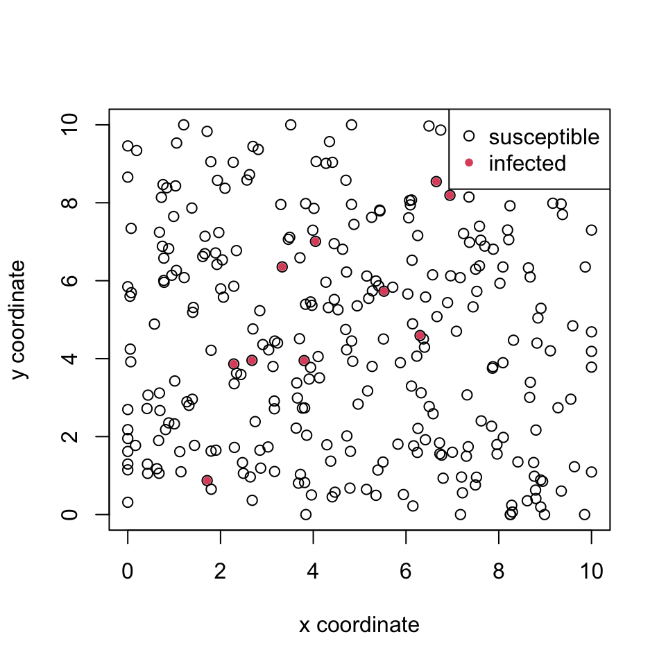

# Transmission dynamics

To specify a transmission event upon contact, we define the transmission probability when two individuals meet and perform a Bernoulli experiment for each social contact between a infected and susceptible individual.

```r
# disease parameters
transmission_prob     = 0.4  # transmission probability per social contact

# identify all infected individuals
boolean_infected = pop_data$health == 'I'   # = vector with Booleans (TRUE/FALSE)
ind_infected     = which(boolean_infected)  # = vector with row indices
num_infected     = length(ind_infected)     # = single value: count data

# we specified the eligible contacts above
#eligible_contacts_matrix

# get indices of infected individuals
#ind_infected

# evaluate the contacts and transmission events for person 1, starting from the contact probability
p_contact_vector    = get_contact_probability(eligible_contacts_matrix, 1)

# exclude contacts with non-susceptible individuals
p_contact_vector[pop_data$health != 'S'] = 0

# sample from binomial distribution, given the contact and transmission probability
binom_infection_vector = rbinom(pop_size, size = 1, prob = p_contact_vector * transmission_prob)

# update population matrix with new infections, if binomial sample == 1
pop_data$health[binom_infection_vector == 1] = 'I'
```

Can you visualize the **newly** infected individuals? (note: you might have different results since we are working with stochastic processes)

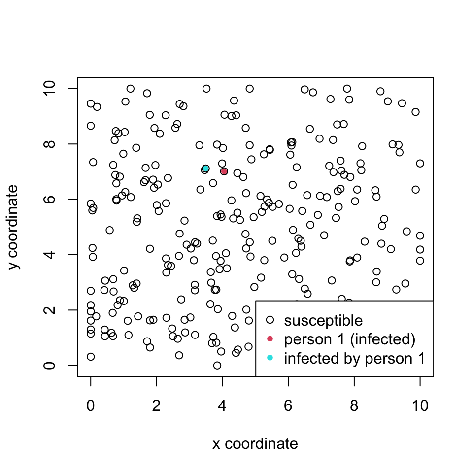

# Recovery

Each time step, we have to account for infected individual that recover. We can handle this using a recovery probability, based on an average number of days infected, and binomial sample.

```r
# set disease parameter: from days infected to recovery rate and a probability
num_days_infected    = 3
recovery_rate = 1 / num_days_infected
recovery_probability = 1 - exp(-recovery_rate)

# we identified the infected individuals above
##boolean_infected = pop_data$health == 'I'

# get vector with a probability to recover for each individual
#(if not infected, the Boolean is FALSE (= 0), the probability is 0)
p_recover_vect = boolean_infected * recovery_probability

# sample individuals that recover
binom_recover_vector = rbinom(pop_size, size = 1, prob = p_recover_vect)

# update population data
pop_data$health[binom_recover_vector == 1] = 'R'
```

Can you visualize the final health states?

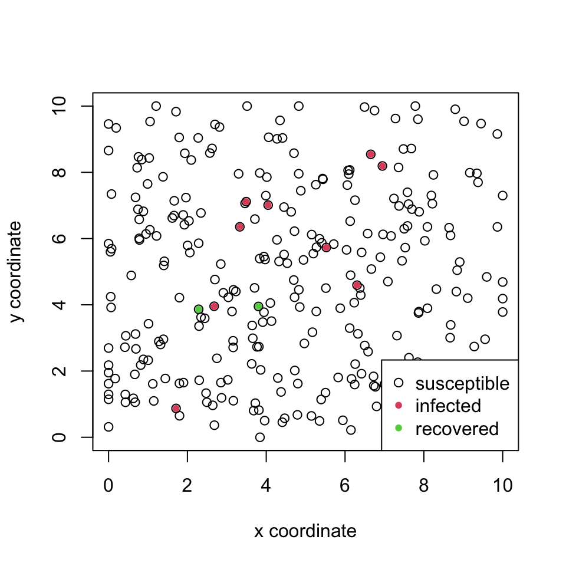